# Summer heat during spermatogenesis in bulls, Fig.4

Author

Jens Vanselow, Claudia Wesenauer, Anja Eggert, Arpna Sharma and Frank Becker

Published

August 31, 2023

# Libraries

```r
library(tidyverse)     # tidy universe
library(lmerTest)      # linear mixed model with pvals
library(emmeans)       # post-hoc
library(performance)   # model performance
library(patchwork)     # combine plots
```

```r
set.seed(1989)
```

# Read data

```r
dat <- read_csv("../data/sperm-motility.csv")
```

## Adjust data types

```r
dat <- dat %>%
  mutate(sample = paste0(generation, "-", time)) %>%
  mutate_at(vars(generation,
                 id,
                 season,
                 time,
                 sample) , ~as.factor(.)) %>%
  mutate(date = lubridate::dmy(date))
```

# Motility, fresh semen

## Data viz & distribution

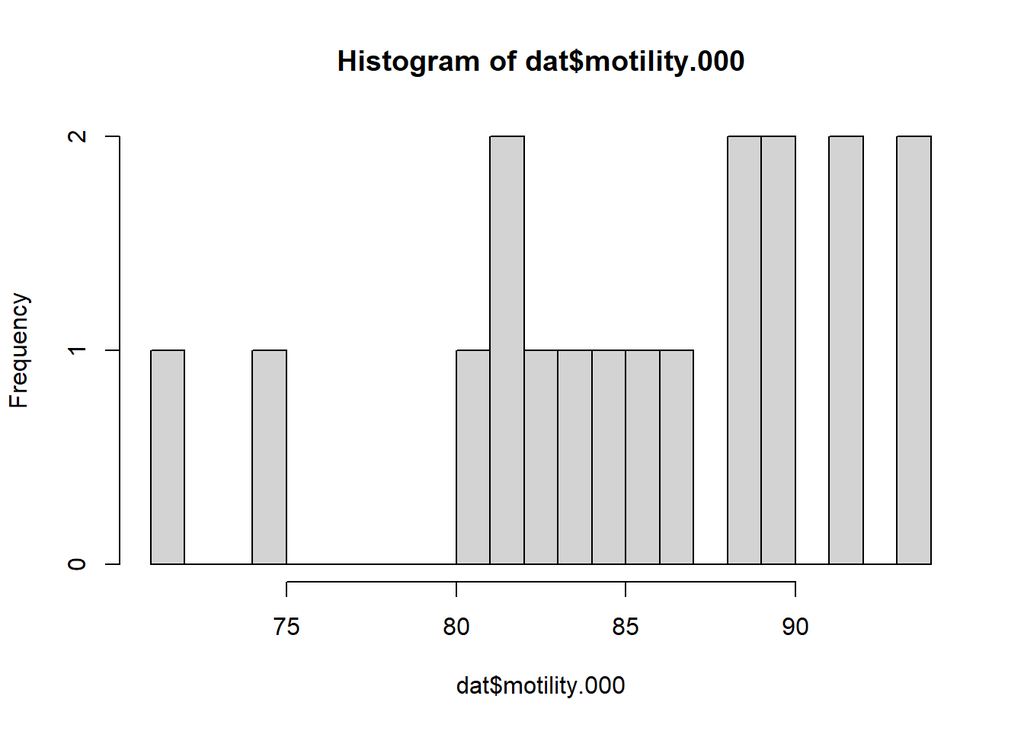

```r
hist(dat$motility.000, breaks = 30)
```

## Linear mixed model

```r
contr = lmerControl(optCtrl = list(maxfun = 10000000),
                    calc.derivs = FALSE)
```

```r
mod.mot.000 <- lmerTest::lmer(motility.000 ~
                                # test predictors
                                season * sample +
                                # no other control predictors
                                # random/nested factors
                                (1|id),
                              data    = dat,
                              REML    = TRUE,
                              control = contr)
```

### Model summary

```r
summary(mod.mot.000)
```

```
Linear mixed model fit by REML. t-tests use Satterthwaite's method [
lmerModLmerTest]
Formula: motility.000 ~ season * sample + (1 | id)
   Data: dat
Control: contr

REML criterion at convergence: 69.4

Scaled residuals:
     Min       1Q   Median       3Q      Max
-1.57929 -0.53638 -0.05163  0.58530  1.98344

Random effects:
 Groups   Name        Variance Std.Dev.
 id       (Intercept)  0.2111  0.4595
 Residual             10.7889  3.2846
Number of obs: 18, groups:  id, 3

Fixed effects:
                            Estimate Std. Error      df t value Pr(>|t|)
(Intercept)                   91.000      1.915  11.978  47.523 5.17e-15 ***
seasonwinter                   1.000      2.682  10.000   0.373 0.717027
sampleF1-early               -14.667      2.682  10.000  -5.469 0.000274 ***
sampleF1-later                -8.667      2.682  10.000  -3.232 0.008997 **
seasonwinter:sampleF1-early    7.333      3.793  10.000   1.933 0.081959 .
seasonwinter:sampleF1-later    5.667      3.793  10.000   1.494 0.166026
---
Signif. codes:  0 '***' 0.001 '**' 0.01 '*' 0.05 '.' 0.1 ' ' 1

Correlation of Fixed Effects:
                 (Intr) ssnwnt smplF1-r smplF1-l ssnwntr:smplF1-r
seasonwintr      -0.700
samplF1-rly      -0.700  0.500
samplF1-ltr      -0.700  0.500  0.500
ssnwntr:smplF1-r  0.495 -0.707 -0.707   -0.354
ssnwntr:smplF1-l  0.495 -0.707 -0.354   -0.707    0.500
```

```r
car::Anova(mod.mot.000, type = "II", test.statistic = "Chisq")
```

```
Analysis of Deviance Table (Type II Wald chisquare tests)

Response: motility.000
                Chisq Df Pr(>Chisq)
season        11.8641  1  0.0005723 ***
sample        33.6869  2  4.841e-08 ***
season:sample  4.1092  2  0.1281463
---
Signif. codes:  0 '***' 0.001 '**' 0.01 '*' 0.05 '.' 0.1 ' ' 1
```

```r
car::Anova(mod.mot.000, type = "II", test.statistic = "F")
```

```
Analysis of Deviance Table (Type II Wald F tests with Kenward-Roger df)

Response: motility.000
                    F Df Df.res    Pr(>F)
season        11.8641  1     10 0.0062846 **
sample        16.8435  2     10 0.0006284 ***
season:sample  2.0546  2     10 0.1788518
---
Signif. codes:  0 '***' 0.001 '**' 0.01 '*' 0.05 '.' 0.1 ' ' 1
```

### Model performance

- some basic checks with functions of package `performance`

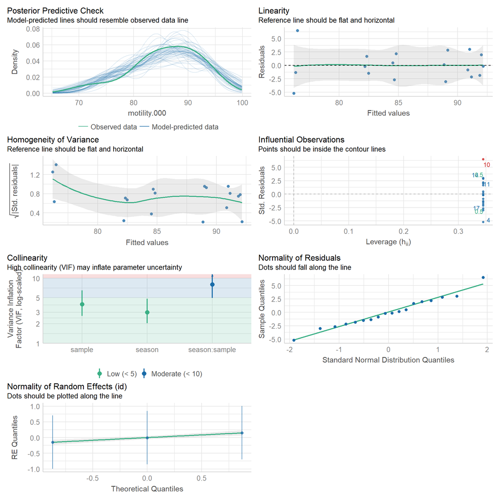

```r
check_model(mod.mot.000)
```

### Estimated Marginal Means

```r
emmeans(mod.mot.000,
        specs  = pairwise ~ season,
        type   = "response",
        adjust = "tukey")
```

```
NOTE: Results may be misleading due to involvement in interactions
```

```
$emmeans
 season emmean   SE   df lower.CL upper.CL
 summer   83.2 1.13 6.19     80.5     86.0
 winter   88.6 1.13 6.19     85.8     91.3

Results are averaged over the levels of: sample
Degrees-of-freedom method: kenward-roger
Confidence level used: 0.95

$contrasts
 contrast        estimate   SE df t.ratio p.value
 summer - winter    -5.33 1.55 10  -3.444  0.0063

Results are averaged over the levels of: sample
Degrees-of-freedom method: kenward-roger
```

```r
emmeans(mod.mot.000,
        specs  = pairwise ~ sample,
        type   = "response",
        adjust = "tukey")
```

```
NOTE: Results may be misleading due to involvement in interactions
```

```
$emmeans
 sample   emmean   SE   df lower.CL upper.CL
 F0-now     91.5 1.37 9.49     88.4     94.6
 F1-early   80.5 1.37 9.49     77.4     83.6
 F1-later   85.7 1.37 9.49     82.6     88.7

Results are averaged over the levels of: season
Degrees-of-freedom method: kenward-roger
Confidence level used: 0.95

$contrasts
 contrast                estimate  SE df t.ratio p.value
 (F0-now) - (F1-early)      11.00 1.9 10   5.800  0.0005
 (F0-now) - (F1-later)       5.83 1.9 10   3.076  0.0289
 (F1-early) - (F1-later)    -5.17 1.9 10  -2.724  0.0514

Results are averaged over the levels of: season
Degrees-of-freedom method: kenward-roger
P value adjustment: tukey method for comparing a family of 3 estimates
```

```r
emm.mot.000 <- emmeans(mod.mot.000,
               specs = pairwise ~ season | sample,
               type = "response",
               adjust = "tukey")
```

```r
emm.mot.000$emmeans
```

```
sample = F0-now:
 season emmean   SE df lower.CL upper.CL
 summer   91.0 1.91 12     86.8     95.2
 winter   92.0 1.91 12     87.8     96.2

sample = F1-early:
 season emmean   SE df lower.CL upper.CL
 summer   76.3 1.91 12     72.2     80.5
 winter   84.7 1.91 12     80.5     88.8

sample = F1-later:
 season emmean   SE df lower.CL upper.CL
 summer   82.3 1.91 12     78.2     86.5
 winter   89.0 1.91 12     84.8     93.2

Degrees-of-freedom method: kenward-roger
Confidence level used: 0.95
```

```r
emm.mot.000$contrasts
```

```
sample = F0-now:
 contrast        estimate   SE df t.ratio p.value
 summer - winter    -1.00 2.68 10  -0.373  0.7170

sample = F1-early:
 contrast        estimate   SE df t.ratio p.value
 summer - winter    -8.33 2.68 10  -3.107  0.0111

sample = F1-later:
 contrast        estimate   SE df t.ratio p.value
 summer - winter    -6.67 2.68 10  -2.486  0.0322

Degrees-of-freedom method: kenward-roger
```

## Plot

- prepare letter display for plots

```r
# cld = compact letter display
cld.mot.000 <- multcomp::cld(emm.mot.000$emmeans, Letters = letters)

# remove whitespace in string in column ".group"
cld.mot.000$.group <- str_replace_all(cld.mot.000$.group, fixed(" "), "")

x <- c("summerF0-now", "winterF0-now",
       "summerF1-early", "winterF1-early",
       "summerF1-later", "winterF1-later")

cld.mot.000 <- as_tibble(cld.mot.000) %>%
  mutate(uniq = paste0(season,sample)) %>%
  mutate(uniq =  factor(uniq, levels = x)) %>%
  arrange(uniq)
```

```r
cld.mot.000
```

```
# A tibble: 6 × 9
  season sample   emmean    SE    df lower.CL upper.CL .group uniq
  <fct>  <fct>     <dbl> <dbl> <dbl>    <dbl>    <dbl> <chr>  <fct>
1 summer F0-now     91.0  1.91  12.0     86.8     95.2 a      summerF0-now
2 winter F0-now     92    1.91  12.0     87.8     96.2 a      winterF0-now
3 summer F1-early   76.3  1.91  12.0     72.2     80.5 a      summerF1-early
4 winter F1-early   84.7  1.91  12.0     80.5     88.8 b      winterF1-early
5 summer F1-later   82.3  1.91  12.0     78.2     86.5 a      summerF1-later
6 winter F1-later   89    1.91  12.0     84.8     93.2 b      winterF1-later
```

```r
# x axis
xlabs.mot.000 <- c("F0 founder \n(summer: 355-375 days) \n(winter: 550-561 days)",
                   "F1 offspring \n(355-375 days)",
                   "F1 offspring \n(398-417 days)")

# prepare x-position of emmeans
cld.mot.000$xpos   <- c(0.8, 1.2, 1.8, 2.2, 2.8, 3.2)
cld.mot.000$xpos.l <- c(0.7, 1.25, 1.7, 2.25, 2.7, 3.25)
```

```r
plot.mot.000 <- dat %>%
  ggplot() +
  geom_point(aes(x = sample,
                 y = motility.000,
                 col = season),
             size = 1.5,
             position = position_jitterdodge(jitter.width = 0,
                                             dodge.width = 0.4)) +
  geom_vline(xintercept = 1.5, linetype = "dashed") +
  scale_colour_manual(name   = "",
                      values = c("orange", "cornflowerblue"),
                      labels = c("F0: summer or F1-S",
                                 "F0: winter or F1-W")) +
  scale_y_continuous(lim = c(0, 100), breaks = seq(0, 100, 20)) +
  scale_x_discrete(labels = xlabs.mot.000) +
  geom_point(data = cld.mot.000,
             aes(x = xpos,
                 y = emmean),
             col = "black", size=1) +
  geom_errorbar(data = cld.mot.000,
                aes(x    = xpos,
                    ymin = emmean-SE,
                    ymax = emmean+SE),
                col="black", width=0.08, size = 0.2) +
  geom_text(data = cld.mot.000,
            aes(x = xpos.l,
                y = emmean,
                label = .group, hjust = 0),
            col="black", size = 8/2.845276) +
  labs(x = "",
       y = c(expression(paste("Proportion of motile dats (%)")))) +
  annotate(geom  = "text",
           x     = 0.5,
           y     = 100,
           label = "Freshly collected semen",
           hjust = -0.05, vjust = -0.05, size = 8/2.845276) +
  my_theme +
  # increase symbol size in legend
  guides(colour = guide_legend(override.aes = list(size = 8/2.845276)))
```

# Motility, thawed semen & 30 min at 40°C

## Data viz & distribution

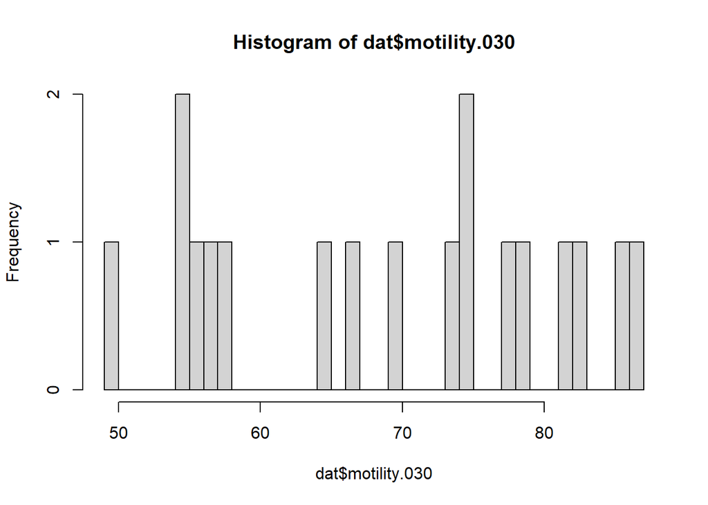

```r
hist(dat$motility.030, breaks = 30)
```

## Linear mixed model

```r
contr = lmerControl(optCtrl = list(maxfun = 10000000),
                    calc.derivs = FALSE)
```

- `(1|id/season)` gives a singular matrix problem, i.e. too complex for too few observations
- interaction `season * sample` not significant and model not different
- boundary (singular) fit: see help(‘isSingular’)

```r
mod.mot.030 <- lmerTest::lmer(motility.030 ~
                                # test predictors
                                season * sample +
                                # no other control predictors
                                # random/nested factors
                                (1|id),
                              data    = dat,
                              REML    = TRUE,
                              control = contr)
```

```
boundary (singular) fit: see help('isSingular')
```

### Model summary

```r
summary(mod.mot.030)
```

```
Linear mixed model fit by REML. t-tests use Satterthwaite's method [
lmerModLmerTest]
Formula: motility.030 ~ season * sample + (1 | id)
   Data: dat
Control: contr

REML criterion at convergence: 92.1

Scaled residuals:
    Min      1Q  Median      3Q     Max
-1.6808 -0.4788 -0.1173  0.6938  1.2899

Random effects:
 Groups   Name        Variance Std.Dev.
 id       (Intercept)  0.00    0.000
 Residual             72.72    8.528
Number of obs: 18, groups:  id, 3

Fixed effects:
                            Estimate Std. Error      df t value Pr(>|t|)
(Intercept)                   79.667      4.923  12.000  16.181 1.63e-09 ***
seasonwinter                   4.333      6.963  12.000   0.622   0.5454
sampleF1-early               -20.667      6.963  12.000  -2.968   0.0117 *
sampleF1-later               -20.333      6.963  12.000  -2.920   0.0128 *
seasonwinter:sampleF1-early    6.000      9.847  12.000   0.609   0.5537
seasonwinter:sampleF1-later    2.000      9.847  12.000   0.203   0.8425
---
Signif. codes:  0 '***' 0.001 '**' 0.01 '*' 0.05 '.' 0.1 ' ' 1

Correlation of Fixed Effects:
                 (Intr) ssnwnt smplF1-r smplF1-l ssnwntr:smplF1-r
seasonwintr      -0.707
samplF1-rly      -0.707  0.500
samplF1-ltr      -0.707  0.500  0.500
ssnwntr:smplF1-r  0.500 -0.707 -0.707   -0.354
ssnwntr:smplF1-l  0.500 -0.707 -0.354   -0.707    0.500
optimizer (nloptwrap) convergence code: 0 (OK)
boundary (singular) fit: see help('isSingular')
```

```r
car::Anova(mod.mot.030, type = "II", test.statistic = "Chisq")
```

```
Analysis of Deviance Table (Type II Wald chisquare tests)

Response: motility.030
                Chisq Df Pr(>Chisq)
season         3.0321  1    0.08163 .
sample        18.9396  2  7.714e-05 ***
season:sample  0.3850  2    0.82488
---
Signif. codes:  0 '***' 0.001 '**' 0.01 '*' 0.05 '.' 0.1 ' ' 1
```

```r
car::Anova(mod.mot.030, type = "II", test.statistic = "F")
```

```
Analysis of Deviance Table (Type II Wald F tests with Kenward-Roger df)

Response: motility.030
                   F Df Df.res   Pr(>F)
season        3.0321  1     10 0.112251
sample        9.4698  2     10 0.004926 **
season:sample 0.1925  2     10 0.827870
---
Signif. codes:  0 '***' 0.001 '**' 0.01 '*' 0.05 '.' 0.1 ' ' 1
```

### Model performance

- some basic checks with functions of package `performance`

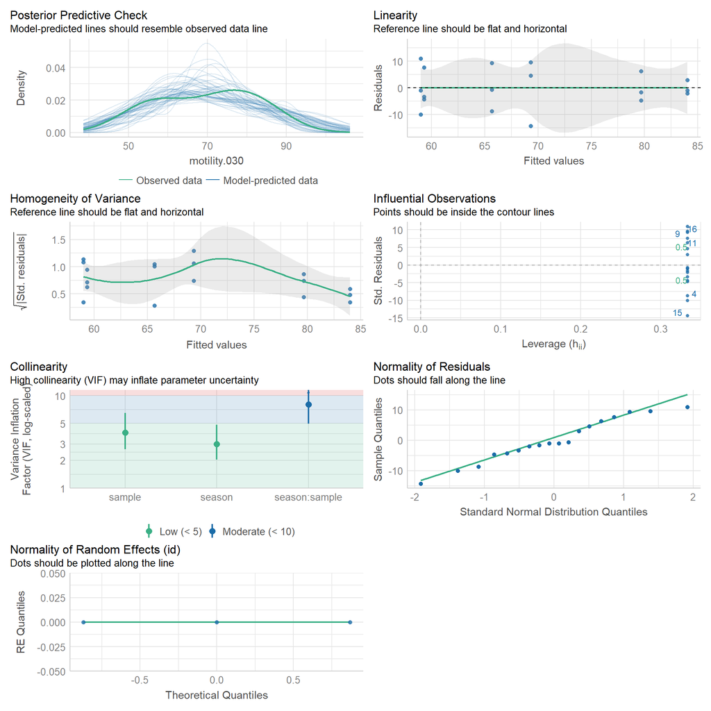

```r
check_model(mod.mot.030)
```

### Estimated Marginal Means

```r
emmeans(mod.mot.030,
        specs  = pairwise ~ season,
        type   = "response",
        adjust = "tukey")
```

```
NOTE: Results may be misleading due to involvement in interactions
```

```
$emmeans
 season emmean   SE   df lower.CL upper.CL
 summer     66 2.84 6.67     59.2     72.8
 winter     73 2.84 6.67     66.2     79.8

Results are averaged over the levels of: sample
Degrees-of-freedom method: kenward-roger
Confidence level used: 0.95

$contrasts
 contrast        estimate   SE df t.ratio p.value
 summer - winter       -7 4.02 10  -1.741  0.1123

Results are averaged over the levels of: sample
Degrees-of-freedom method: kenward-roger
```

```r
emmeans(mod.mot.030,
        specs  = pairwise ~ sample,
        type   = "response",
        adjust = "tukey")
```

```
NOTE: Results may be misleading due to involvement in interactions
```

```
$emmeans
 sample   emmean   SE df lower.CL upper.CL
 F0-now     81.8 3.48 10     74.1     89.6
 F1-early   64.2 3.48 10     56.4     71.9
 F1-later   62.5 3.48 10     54.7     70.3

Results are averaged over the levels of: season
Degrees-of-freedom method: kenward-roger
Confidence level used: 0.95

$contrasts
 contrast                estimate   SE df t.ratio p.value
 (F0-now) - (F1-early)      17.67 4.92 10   3.588  0.0125
 (F0-now) - (F1-later)      19.33 4.92 10   3.927  0.0073
 (F1-early) - (F1-later)     1.67 4.92 10   0.339  0.9392

Results are averaged over the levels of: season
Degrees-of-freedom method: kenward-roger
P value adjustment: tukey method for comparing a family of 3 estimates
```

```r
emm.mot.030 <- emmeans(mod.mot.030,
                       specs = pairwise ~ season | sample,
                       type = "response",
                       adjust = "tukey")
```

```r
emm.mot.030$emmeans
```

```
sample = F0-now:
 season emmean   SE df lower.CL upper.CL
 summer   79.7 4.92 12     68.9     90.4
 winter   84.0 4.92 12     73.3     94.7

sample = F1-early:
 season emmean   SE df lower.CL upper.CL
 summer   59.0 4.92 12     48.3     69.7
 winter   69.3 4.92 12     58.6     80.1

sample = F1-later:
 season emmean   SE df lower.CL upper.CL
 summer   59.3 4.92 12     48.6     70.1
 winter   65.7 4.92 12     54.9     76.4

Degrees-of-freedom method: kenward-roger
Confidence level used: 0.95
```

```r
emm.mot.030$contrasts
```

```
sample = F0-now:
 contrast        estimate   SE df t.ratio p.value
 summer - winter    -4.33 6.96 10  -0.622  0.5476

sample = F1-early:
 contrast        estimate   SE df t.ratio p.value
 summer - winter   -10.33 6.96 10  -1.484  0.1686

sample = F1-later:
 contrast        estimate   SE df t.ratio p.value
 summer - winter    -6.33 6.96 10  -0.910  0.3844

Degrees-of-freedom method: kenward-roger
```

## Plot

- prepare letter display for plots

```r
# cld = compact letter display
cld.mot.030 <- multcomp::cld(emm.mot.030$emmeans, Letters = letters)

# remove whitespace in string in column ".group"
cld.mot.030$.group <- str_replace_all(cld.mot.030$.group, fixed(" "), "")

x <- c("summerF0-now", "winterF0-now",
       "summerF1-early", "winterF1-early",
       "summerF1-later", "winterF1-later")

cld.mot.030 <- as_tibble(cld.mot.030) %>%
  mutate(uniq = paste0(season,sample)) %>%
  mutate(uniq =  factor(uniq, levels = x)) %>%
  arrange(uniq)
```

```r
cld.mot.030
```

```
# A tibble: 6 × 9
  season sample   emmean    SE    df lower.CL upper.CL .group uniq
  <fct>  <fct>     <dbl> <dbl> <dbl>    <dbl>    <dbl> <chr>  <fct>
1 summer F0-now     79.7  4.92  12.0     68.9     90.4 a      summerF0-now
2 winter F0-now     84    4.92  12       73.3     94.7 a      winterF0-now
3 summer F1-early   59    4.92  12.0     48.3     69.7 a      summerF1-early
4 winter F1-early   69.3  4.92  12.0     58.6     80.1 a      winterF1-early
5 summer F1-later   59.3  4.92  12       48.6     70.1 a      summerF1-later
6 winter F1-later   65.7  4.92  12.0     54.9     76.4 a      winterF1-later
```

```r
# x axis
xlabs.mot.030 <- c("F0 founder \n(summer: 355-375 days) \n(winter: 550-561 days)",
                   "F1 offspring \n(355-375 days)",
                   "F1 offspring \n(398-417 days)")

# prepare x-position of emmeans
cld.mot.030$xpos   <- c(0.8, 1.2, 1.8, 2.2, 2.8, 3.2)
cld.mot.030$xpos.l <- c(0.7, 1.25, 1.7, 2.25, 2.7, 3.25)
```

```r
plot.mot.030 <- dat %>%
  ggplot() +
  geom_point(aes(x = sample,
                 y = motility.030,
                 col = season),
             size = 1.5,
             position = position_jitterdodge(jitter.width = 0,
                                             dodge.width  = 0.4)) +
  geom_vline(xintercept = 1.5, linetype = "dashed") +
  scale_colour_manual(name = "",
                      values = c("orange", "cornflowerblue"),
                      labels = c("F0: summer or F1-S",
                                 "F0: winter or F1-W")) +
  scale_y_continuous(lim = c(0, 100), breaks = seq(0, 100, 20)) +
  scale_x_discrete(labels = xlabs.mot.030) +
  geom_point(data = cld.mot.030,
             aes(x = xpos,
                 y = emmean),
             col = "black", size = 1) +
  geom_errorbar(data = cld.mot.030,
                aes(x    = xpos,
                    ymin = emmean-SE,
                    ymax = emmean+SE),
                col = "black", width = 0.08, size = 0.2) +
  geom_text(data = cld.mot.030,
            aes(x = xpos.l,
                y = emmean,
                label = .group, hjust = 0),
            col = "black", size = 8/2.845276) +
  labs(x = "",
       y = c(expression(paste("Proportion of motile sperms (%)")))) +
  annotate(geom  = "text",
           x     = 0.5,
           y     = 100,
           label = "Frozen & re-thawed semen & 30 min at 40°C",
           hjust = -0.05, vjust = -0.05, size = 8/2.845276) +
  my_theme +
  # increase symbol size in legend
  guides(colour = guide_legend(override.aes = list(size = 8/2.845276)))
```

# Motility, thawed semen & 120 min at 40°C

## Data viz & distribution

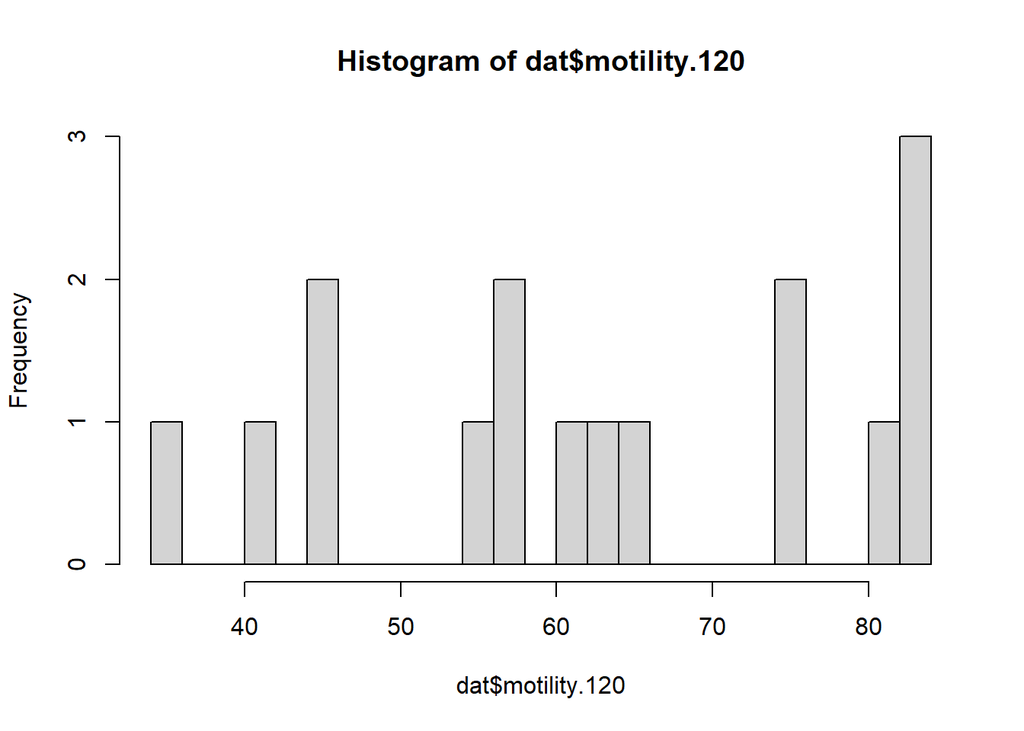

```r
hist(dat$motility.120, breaks = 30)
```

## Linear mixed model

```r
contr = lmerControl(optCtrl = list(maxfun = 10000000),
                    calc.derivs = FALSE)
```

- `(1|id/season)` gives a singular matrix problem, i.e. too complex for too few observations
- interaction `season * sample` not significant and model not different
- boundary (singular) fit: see help(‘isSingular’)

```r
mod.mot.120 <- lmerTest::lmer(motility.120 ~
                                # test predictors
                                season * sample +
                                # no other control predictors
                                # random/nested factors
                                (1|id),
                              data    = dat,
                              REML    = TRUE,
                              control = contr)
```

```
boundary (singular) fit: see help('isSingular')
```

### Model summary

```r
summary(mod.mot.120)
```

```
Linear mixed model fit by REML. t-tests use Satterthwaite's method [
lmerModLmerTest]
Formula: motility.120 ~ season * sample + (1 | id)
   Data: dat
Control: contr

REML criterion at convergence: 81.1

Scaled residuals:
     Min       1Q   Median       3Q      Max
-1.36850 -0.41771 -0.06365  0.54501  1.59128

Random effects:
 Groups   Name        Variance Std.Dev.
 id       (Intercept)   0.0     0.00
 Residual             109.7    10.47
Number of obs: 16, groups:  id, 3

Fixed effects:
                            Estimate Std. Error      df t value Pr(>|t|)
(Intercept)                   76.667      6.047  10.000  12.678 1.74e-07 ***
seasonwinter                   3.333      8.552  10.000   0.390  0.70487
sampleF1-early               -33.333      8.552  10.000  -3.898  0.00297 **
sampleF1-later               -25.167      9.561  10.000  -2.632  0.02507 *
seasonwinter:sampleF1-early   16.833     12.828  10.000   1.312  0.21875
seasonwinter:sampleF1-later    4.500     12.828  10.000   0.351  0.73301
---
Signif. codes:  0 '***' 0.001 '**' 0.01 '*' 0.05 '.' 0.1 ' ' 1

Correlation of Fixed Effects:
                 (Intr) ssnwnt smplF1-r smplF1-l ssnwntr:smplF1-r
seasonwintr      -0.707
samplF1-rly      -0.707  0.500
samplF1-ltr      -0.632  0.447  0.447
ssnwntr:smplF1-r  0.471 -0.667 -0.667   -0.298
ssnwntr:smplF1-l  0.471 -0.667 -0.333   -0.745    0.444
optimizer (nloptwrap) convergence code: 0 (OK)
boundary (singular) fit: see help('isSingular')
```

```r
car::Anova(mod.mot.120, type = "II", test.statistic = "Chisq")
```

```
Analysis of Deviance Table (Type II Wald chisquare tests)

Response: motility.120
                Chisq Df Pr(>Chisq)
season         3.4826  1    0.06202 .
sample        20.7517  2  3.118e-05 ***
season:sample  1.7894  2    0.40874
---
Signif. codes:  0 '***' 0.001 '**' 0.01 '*' 0.05 '.' 0.1 ' ' 1
```

```r
car::Anova(mod.mot.120, type = "II", test.statistic = "F")
```

```
Analysis of Deviance Table (Type II Wald F tests with Kenward-Roger df)

Response: motility.120
                    F Df Df.res   Pr(>F)
season         3.4826  1 8.0769 0.098635 .
sample        10.3129  2 8.1914 0.005788 **
season:sample  0.8389  2 8.6323 0.464583
---
Signif. codes:  0 '***' 0.001 '**' 0.01 '*' 0.05 '.' 0.1 ' ' 1
```

### Model performance

- some basic checks with functions of package `performance`

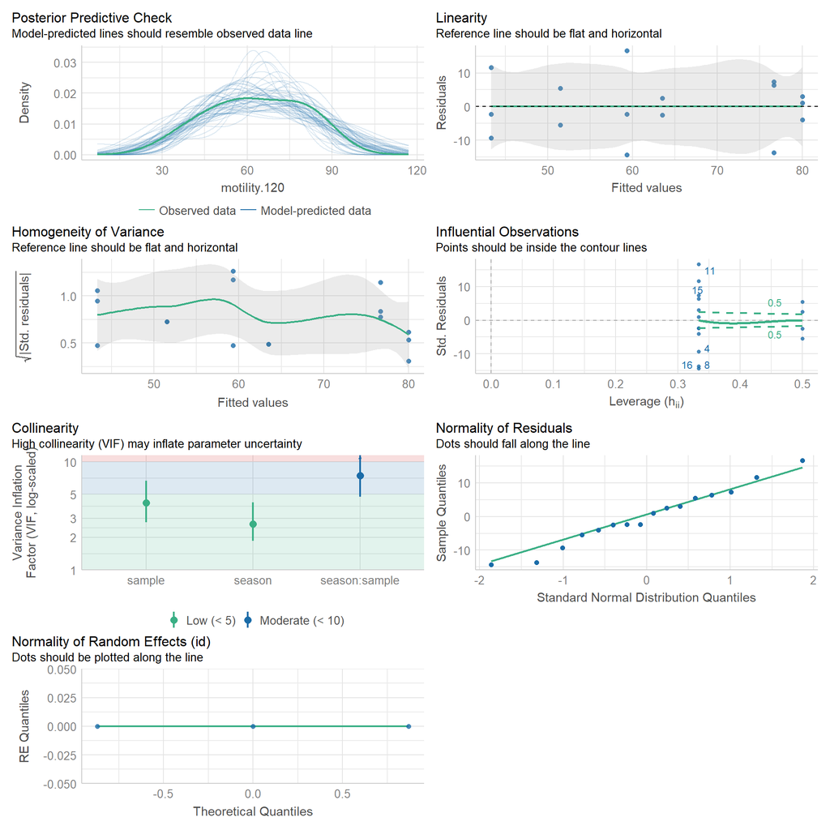

```r
check_model(mod.mot.120)
```

### Estimated Marginal Means

```r
emmeans(mod.mot.120,
        specs  = pairwise ~ season,
        type   = "response",
        adjust = "tukey")
```

```
NOTE: Results may be misleading due to involvement in interactions
```

```
$emmeans
 season emmean   SE   df lower.CL upper.CL
 summer   57.2 3.87 5.88     47.6     66.7
 winter   67.6 3.87 5.88     58.1     77.1

Results are averaged over the levels of: sample
Degrees-of-freedom method: kenward-roger
Confidence level used: 0.95

$contrasts
 contrast        estimate   SE   df t.ratio p.value
 summer - winter    -10.4 5.33 8.08  -1.958  0.0855

Results are averaged over the levels of: sample
Degrees-of-freedom method: kenward-roger
```

```r
emmeans(mod.mot.120,
        specs  = pairwise ~ sample,
        type   = "response",
        adjust = "tukey")
```

```
NOTE: Results may be misleading due to involvement in interactions
```

```
$emmeans
 sample   emmean   SE   df lower.CL upper.CL
 F0-now     78.3 4.28 8.08     68.5     88.2
 F1-early   53.4 4.96 8.68     42.1     64.7
 F1-later   55.4 4.96 8.68     44.1     66.7

Results are averaged over the levels of: season
Degrees-of-freedom method: kenward-roger
Confidence level used: 0.95

$contrasts
 contrast                estimate   SE   df t.ratio p.value
 (F0-now) - (F1-early)       24.9 6.55 8.42   3.805  0.0118
 (F0-now) - (F1-later)       22.9 6.55 8.42   3.500  0.0183
 (F1-early) - (F1-later)     -2.0 6.76 8.08  -0.296  0.9532

Results are averaged over the levels of: season
Degrees-of-freedom method: kenward-roger
P value adjustment: tukey method for comparing a family of 3 estimates
```

```r
emm.mot.120 <- emmeans(mod.mot.120,
               specs = pairwise ~ season | sample,
               type = "response",
               adjust = "tukey")
```

```r
emm.mot.120$emmeans
```

```
sample = F0-now:
 season emmean   SE df lower.CL upper.CL
 summer   76.7 6.05 10     63.2     90.1
 winter   80.0 6.05 10     66.5     93.5

sample = F1-early:
 season emmean   SE df lower.CL upper.CL
 summer   43.3 6.05 10     29.9     56.8
 winter   63.5 7.86 10     46.0     81.0

sample = F1-later:
 season emmean   SE df lower.CL upper.CL
 summer   51.5 7.86 10     34.0     69.0
 winter   59.3 6.05 10     45.9     72.8

Degrees-of-freedom method: kenward-roger
Confidence level used: 0.95
```

```r
emm.mot.120$contrasts
```

```
sample = F0-now:
 contrast        estimate   SE   df t.ratio p.value
 summer - winter    -3.33 8.55 8.08  -0.390  0.7068

sample = F1-early:
 contrast        estimate   SE   df t.ratio p.value
 summer - winter   -20.17 9.92 8.68  -2.033  0.0737

sample = F1-later:
 contrast        estimate   SE   df t.ratio p.value
 summer - winter    -7.83 9.92 8.68  -0.790  0.4507

Degrees-of-freedom method: kenward-roger
```

## Plot

- prepare letter display for plots

```r
# cld = compact letter display
cld.mot.120 <- multcomp::cld(emm.mot.120$emmeans, Letters = letters)

# remove whitespace in string in column ".group"
cld.mot.120$.group <- str_replace_all(cld.mot.120$.group, fixed(" "), "")

x <- c("summerF0-now", "winterF0-now",
       "summerF1-early", "winterF1-early",
       "summerF1-later", "winterF1-later")

cld.mot.120 <- as_tibble(cld.mot.120) %>%
  mutate(uniq = paste0(season,sample)) %>%
  mutate(uniq =  factor(uniq, levels = x)) %>%
  arrange(uniq)
```

```r
cld.mot.120
```

```
# A tibble: 6 × 9
  season sample   emmean    SE    df lower.CL upper.CL .group uniq
  <fct>  <fct>     <dbl> <dbl> <dbl>    <dbl>    <dbl> <chr>  <fct>
1 summer F0-now     76.7  6.05  10.0     63.2     90.1 a      summerF0-now
2 winter F0-now     80    6.05  10       66.5     93.5 a      winterF0-now
3 summer F1-early   43.3  6.05  10.0     29.9     56.8 a      summerF1-early
4 winter F1-early   63.5  7.86  10       46.0     81.0 a      winterF1-early
5 summer F1-later   51.5  7.86  10.0     34.0     69.0 a      summerF1-later
6 winter F1-later   59.3  6.05  10       45.9     72.8 a      winterF1-later
```

```r
# x axis
xlabs.mot.120 <- c("F0 founder \n(summer: 355-375 days) \n(winter: 550-561 days)",
                   "F1 offspring \n(355-375 days)",
                   "F1 offspring \n(398-417 days)")

# prepare x-position of emmeans
cld.mot.120$xpos   <- c(0.8, 1.2, 1.8, 2.2, 2.8, 3.2)
cld.mot.120$xpos.l <- c(0.7, 1.25, 1.7, 2.25, 2.7, 3.25)
```

```r
plot.mot.120 <- dat %>%
  ggplot() +
  geom_point(aes(x = sample,
                 y = motility.120,
                 col = season),
             size = 1.5,
             position = position_jitterdodge(jitter.width = 0,
                                             dodge.width = 0.4)) +
  geom_vline(xintercept = 1.5, linetype = "dashed") +
  scale_colour_manual(name   = "",
                      values = c("orange", "cornflowerblue"),
                      labels = c("F0: summer or F1-S",
                                 "F0: winter or F1-W")) +
  scale_y_continuous(lim = c(0, 100), breaks = seq(0, 100, 20)) +
  scale_x_discrete(labels = xlabs.mot.120) +
  geom_point(data = cld.mot.120,
             aes(x = xpos,
                 y = emmean),
             col = "black", size = 1) +
  geom_errorbar(data = cld.mot.120,
                aes(x    = xpos,
                    ymin = emmean-SE,
                    ymax = emmean+SE),
                col = "black", width = 0.08, size = 0.2) +
  geom_text(data = cld.mot.120,
            aes(x = xpos.l,
                y = emmean,
                label = .group, hjust = 0),
            col = "black", size = 8/2.845276) +
  labs(x = "",
       y = c(expression(paste("Proportion of motile sperms (%)")))) +
  annotate(geom  = "text",
           x     = 0.5,
           y     = 100,
           label = "Frozen & re-thawed semen & 120 min at 40°C",
           hjust = -0.05, vjust = -0.05, size = 8/2.845276) +
  my_theme +
  # increase symbol size in legend
  guides(colour = guide_legend(override.aes = list(size = 8/2.845276)))
```

# Combined plot: all motilities

```r
plot.mot.000.noaxis <- plot.mot.000 +
  theme(axis.title.x = element_blank(),
        axis.text.x  = element_blank())

plot.mot.030.noaxis <- plot.mot.030 +
  theme(axis.title.x = element_blank(),
        axis.text.x  = element_blank())

patch.mot <- plot.mot.000.noaxis / plot.mot.030.noaxis / plot.mot.120 +
  plot_annotation(tag_levels = 'A',
                  tag_prefix = '(',
                  tag_suffix = ')') +
  plot_layout(guides = 'collect') &
  theme(plot.tag          = element_text(face = 'bold', size = 8),
        legend.position   = 'top',
        legend.background = element_rect(fill      = NA,
                                         colour    = "black",
                                         linewidth = 0.3,
                                         linetype  = "solid"))
```

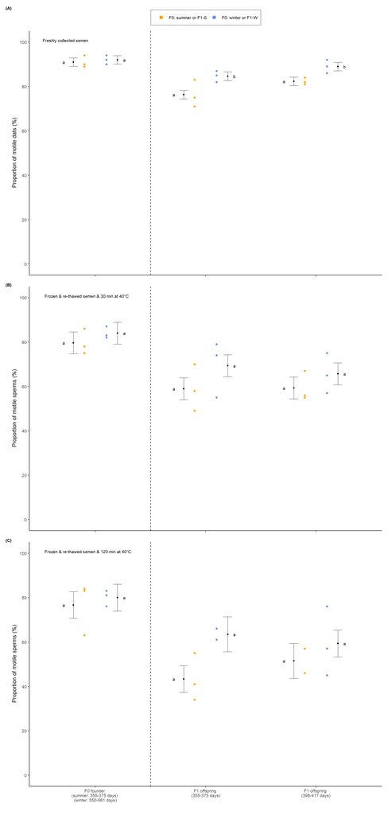

```r
patch.mot
```

# How to cite R

“All analyses were performed using R Statistical Software (version 4.2.0; R Core Team 2022)”.

Reference: R Core Team (2022). R: A language and environment for statistical computing. R Foundation for Statistical Computing, Vienna, Austria. URL https://www.R-project.org/.

```r
citation()
```

```
  R Core Team (2022). R: A language and environment for statistical
  computing. R Foundation for Statistical Computing, Vienna, Austria.
  URL https://www.R-project.org/.

Ein BibTeX-Eintrag für LaTeX-Benutzer ist

  @Manual{,
    title = {R: A Language and Environment for Statistical Computing},
    author = {{R Core Team}},
    organization = {R Foundation for Statistical Computing},
    address = {Vienna, Austria},
    year = {2022},
    url = {https://www.R-project.org/},
  }

We have invested a lot of time and effort in creating R, please cite it
when using it for data analysis. See also 'citation("pkgname")' for
citing R packages.
```

```r
version$version.string
```

```
[1] "R version 4.2.0 (2022-04-22 ucrt)"
```

```r
citation("tidyverse")
```

```
Um Paket 'tidyverse' in Publikationen zu zitieren, nutzen Sie bitte:

  Wickham H, Averick M, Bryan J, Chang W, McGowan LD, François R,
  Grolemund G, Hayes A, Henry L, Hester J, Kuhn M, Pedersen TL, Miller
  E, Bache SM, Müller K, Ooms J, Robinson D, Seidel DP, Spinu V,
  Takahashi K, Vaughan D, Wilke C, Woo K, Yutani H (2019). "Welcome to
  the tidyverse." _Journal of Open Source Software_, *4*(43), 1686.
  doi:10.21105/joss.01686 <https://doi.org/10.21105/joss.01686>.

Ein BibTeX-Eintrag für LaTeX-Benutzer ist

  @Article{,
    title = {Welcome to the {tidyverse}},
    author = {Hadley Wickham and Mara Averick and Jennifer Bryan and Winston Chang and Lucy D'Agostino McGowan and Romain François and Garrett Grolemund and Alex Hayes and Lionel Henry and Jim Hester and Max Kuhn and Thomas Lin Pedersen and Evan Miller and Stephan Milton Bache and Kirill Müller and …
    year = {2019},
    journal = {Journal of Open Source Software},
    volume = {4},
    number = {43},
    pages = {1686},
    doi = {10.21105/joss.01686},
  }
```

```r
citation("lmerTest")
```

```
  Kuznetsova A, Brockhoff PB, Christensen RHB (2017). "lmerTest
  Package: Tests in Linear Mixed Effects Models." _Journal of
  Statistical Software_, *82*(13), 1-26. doi:10.18637/jss.v082.i13
  <https://doi.org/10.18637/jss.v082.i13>.

Ein BibTeX-Eintrag für LaTeX-Benutzer ist

  @Article{,
    title = {{lmerTest} Package: Tests in Linear Mixed Effects Models},
    author = {Alexandra Kuznetsova and Per B. Brockhoff and Rune H. B. Christensen},
    journal = {Journal of Statistical Software},
    year = {2017},
    volume = {82},
    number = {13},
    pages = {1--26},
    doi = {10.18637/jss.v082.i13},
  }
```

```r
citation("emmeans")
```

```
Um Paket 'emmeans' in Publikationen zu zitieren, nutzen Sie bitte:

  Lenth R (2023). _emmeans: Estimated Marginal Means, aka Least-Squares
  Means_. R package version 1.8.6,
  <https://CRAN.R-project.org/package=emmeans>.

Ein BibTeX-Eintrag für LaTeX-Benutzer ist

  @Manual{,
    title = {emmeans: Estimated Marginal Means, aka Least-Squares Means},
    author = {Russell V. Lenth},
    year = {2023},
    note = {R package version 1.8.6},
    url = {https://CRAN.R-project.org/package=emmeans},
  }
```

```r
citation("performance")
```

```
Um Paket 'performance' in Publikationen zu zitieren, nutzen Sie bitte:

  Lüdecke et al., (2021). performance: An R Package for Assessment,
  Comparison and Testing of Statistical Models. Journal of Open Source
  Software, 6(60), 3139. https://doi.org/10.21105/joss.03139

Ein BibTeX-Eintrag für LaTeX-Benutzer ist

  @Article{,
    title = {{performance}: An {R} Package for Assessment, Comparison and Testing of Statistical Models},
    author = {Daniel Lüdecke and Mattan S. Ben-Shachar and Indrajeet Patil and Philip Waggoner and Dominique Makowski},
    year = {2021},
    journal = {Journal of Open Source Software},
    volume = {6},
    number = {60},
    pages = {3139},
    doi = {10.21105/joss.03139},
  }
```

```r
citation("patchwork")
```

```
Um Paket 'patchwork' in Publikationen zu zitieren, nutzen Sie bitte:

  Pedersen T (2022). _patchwork: The Composer of Plots_. R package
  version 1.1.2, <https://CRAN.R-project.org/package=patchwork>.

Ein BibTeX-Eintrag für LaTeX-Benutzer ist

  @Manual{,
    title = {patchwork: The Composer of Plots},
    author = {Thomas Lin Pedersen},
    year = {2022},
    note = {R package version 1.1.2},
    url = {https://CRAN.R-project.org/package=patchwork},
  }
```